# Analysis of FitBit data

Mikołaj Sobora

2024-07-16

## Case Study

This is my first case study, showcasing acquired skills in R Programming. For this purpose I will use public data that explores habits of smart device users’ daily habits.

DATASET: FitBit Fitness Tracker Data (CC0: Public Domain, dataset made available through Mobius): This Kaggle data set contains personal fitness tracker from thirty fitbit users. Thirty eligible Fitbit users consented to the submission of personal tracker data, including minute-level output for physical activity, heart rate, and sleep monitoring. It includes information about daily activity, steps, and heart rate that can be used to explore users’ habits.

### Prepare

- Setting up my environment.

I dowloaded the dataset from Kaggle in .csv format and saved it on my harddrive. Then in Rstudio I installed necessary packages to proceed with my task.

```r
install.packages("tidyverse", repos = "http://cran.us.r-project.org")
install.packages("data.table", repos = "http://cran.us.r-project.org")
install.packages("rmarkdown", repos = "http://cran.us.r-project.org")
library(data.table)
library(readr)
library(dplyr)
library(tidyr)
library(skimr)
library(janitor)
library(lubridate)
library(ggplot2)
library(scales)
library(rmarkdown)
```

Then I set my working directory to the file in which I saved this dataset using setwd() function and proceeded to load the .csv files.

```r
hourly_calories <- read.csv("mturkfitbit_export_3.12.16-4.11.16/Fitabase Data 3.12.16-4.11.16/hourlyCalories_merged.csv")
hourly_intensities <- read.csv("mturkfitbit_export_3.12.16-4.11.16/Fitabase Data 3.12.16-4.11.16/hourlyIntensities_merged.csv")
hourly_steps <- read.csv("mturkfitbit_export_3.12.16-4.11.16/Fitabase Data 3.12.16-4.11.16/hourlySteps_merged.csv")
weight_log_info <- read.csv("mturkfitbit_export_3.12.16-4.11.16/Fitabase Data 3.12.16-4.11.16/weightLogInfo_merged.csv")
daily_activity <- read.csv("mturkfitbit_export_4.12.16-5.12.16/Fitabase Data 4.12.16-5.12.16/dailyActivity_merged.csv")
sleep_day <- read.csv("mturkfitbit_export_4.12.16-5.12.16/Fitabase Data 4.12.16-5.12.16/sleepDay_merged.csv")
```

- Getting acquainted with the data.

After uploading all files into RStudio I began to examine it. I created an object containing all files to make my work more time efficient.

```r
all_files <- c(hourly_calories, hourly_intensities, hourly_steps, weight_log_info, daily_activity, sleep_day)
```

First I used glimpse() to get some insights from the data.

```r
glimpse(all_files)
```

```
## List of 38
##  $ Id                      : num [1:24084] 1.5e+09 1.5e+09 1.5e+09 1.5e+09 1.5e+09 ...
##  $ ActivityHour            : chr [1:24084] "3/12/2016 12:00:00 AM" "3/12/2016 1:00:00 AM" "3/12/2016 2:00:00 AM" "3/12/2016 3:00:00 AM" ...
##  $ Calories                : int [1:24084] 48 48 48 48 48 48 48 48 48 49 ...
##  $ Id                      : num [1:24084] 1.5e+09 1.5e+09 1.5e+09 1.5e+09 1.5e+09 ...
##  $ ActivityHour            : chr [1:24084] "3/12/2016 12:00:00 AM" "3/12/2016 1:00:00 AM" "3/12/2016 2:00:00 AM" "3/12/2016 3:00:00 AM" ...
##  $ TotalIntensity          : int [1:24084] 0 0 0 0 0 0 0 0 0 1 ...
##  $ AverageIntensity        : num [1:24084] 0 0 0 0 0 ...
##  $ Id                      : num [1:24084] 1.5e+09 1.5e+09 1.5e+09 1.5e+09 1.5e+09 ...
##  $ ActivityHour            : chr [1:24084] "3/12/2016 12:00:00 AM" "3/12/2016 1:00:00 AM" "3/12/2016 2:00:00 AM" "3/12/2016 3:00:00 AM" ...
##  $ StepTotal               : int [1:24084] 0 0 0 0 0 0 0 0 0 8 ...
##  $ Id                      : num [1:33] 1.50e+09 1.93e+09 2.35e+09 2.87e+09 2.87e+09 ...
##  $ Date                    : chr [1:33] "4/5/2016 11:59:59 PM" "4/10/2016 6:33:26 PM" "4/3/2016 11:59:59 PM" "4/6/2016 11:59:59 PM" ...
##  $ WeightKg                : num [1:33] 53.3 129.6 63.4 56.7 57.2 ...
##  $ WeightPounds            : num [1:33] 118 286 140 125 126 ...
```

[output cut: 24 more lines]

Then to get more details about each file I used head() function.

```r
head(hourly_calories)
```

```
##           Id          ActivityHour Calories
## 1 1503960366 3/12/2016 12:00:00 AM       48
## 2 1503960366  3/12/2016 1:00:00 AM       48
## 3 1503960366  3/12/2016 2:00:00 AM       48
## 4 1503960366  3/12/2016 3:00:00 AM       48
## 5 1503960366  3/12/2016 4:00:00 AM       48
## 6 1503960366  3/12/2016 5:00:00 AM       48
```

```r
head(hourly_intensities)
```

```
##           Id          ActivityHour TotalIntensity AverageIntensity
## 1 1503960366 3/12/2016 12:00:00 AM              0                0
## 2 1503960366  3/12/2016 1:00:00 AM              0                0
## 3 1503960366  3/12/2016 2:00:00 AM              0                0
## 4 1503960366  3/12/2016 3:00:00 AM              0                0
## 5 1503960366  3/12/2016 4:00:00 AM              0                0
## 6 1503960366  3/12/2016 5:00:00 AM              0                0
```

```r
head(hourly_steps)
```

```
##           Id          ActivityHour StepTotal
## 1 1503960366 3/12/2016 12:00:00 AM         0
## 2 1503960366  3/12/2016 1:00:00 AM         0
## 3 1503960366  3/12/2016 2:00:00 AM         0
## 4 1503960366  3/12/2016 3:00:00 AM         0
## 5 1503960366  3/12/2016 4:00:00 AM         0
## 6 1503960366  3/12/2016 5:00:00 AM         0
```

```r
head(weight_log_info)
```

```
##           Id                 Date WeightKg WeightPounds Fat   BMI
## 1 1503960366 4/5/2016 11:59:59 PM     53.3     117.5064  22 22.97
## 2 1927972279 4/10/2016 6:33:26 PM    129.6     285.7191  NA 46.17
## 3 2347167796 4/3/2016 11:59:59 PM     63.4     139.7731  10 24.77
## 4 2873212765 4/6/2016 11:59:59 PM     56.7     125.0021  NA 21.45
## 5 2873212765 4/7/2016 11:59:59 PM     57.2     126.1044  NA 21.65
## 6 2891001357 4/5/2016 11:59:59 PM     88.4     194.8886  NA 25.03
##   IsManualReport        LogId
## 1           True 1.459901e+12
## 2          False 1.460313e+12
## 3           True 1.459728e+12
## 4           True 1.459987e+12
## 5           True 1.460074e+12
## 6           True 1.459901e+12
```

```r
head(daily_activity)
```

```
##           Id ActivityDate TotalSteps TotalDistance TrackerDistance
## 1 1503960366    4/12/2016      13162          8.50            8.50
## 2 1503960366    4/13/2016      10735          6.97            6.97
## 3 1503960366    4/14/2016      10460          6.74            6.74
## 4 1503960366    4/15/2016       9762          6.28            6.28
## 5 1503960366    4/16/2016      12669          8.16            8.16
## 6 1503960366    4/17/2016       9705          6.48            6.48
##   LoggedActivitiesDistance VeryActiveDistance ModeratelyActiveDistance
## 1                        0               1.88                     0.55
## 2                        0               1.57                     0.69
## 3                        0               2.44                     0.40
## 4                        0               2.14                     1.26
## 5                        0               2.71                     0.41
## 6                        0               3.19                     0.78
##   LightActiveDistance SedentaryActiveDistance VeryActiveMinutes
## 1                6.06                       0                25
## 2                4.71                       0                21
## 3                3.91                       0                30
## 4                2.83                       0                29
## 5                5.04                       0                36
## 6                2.51                       0                38
##   FairlyActiveMinutes LightlyActiveMinutes SedentaryMinutes Calories
## 1                  13                  328              728     1985
## 2                  19                  217              776     1797
## 3                  11                  181             1218     1776
## 4                  34                  209              726     1745
## 5                  10                  221              773     1863
## 6                  20                  164              539     1728
```

```r
head(sleep_day)
```

```
##           Id              SleepDay TotalSleepRecords TotalMinutesAsleep
## 1 1503960366 4/12/2016 12:00:00 AM                 1                327
## 2 1503960366 4/13/2016 12:00:00 AM                 2                384
## 3 1503960366 4/15/2016 12:00:00 AM                 1                412
## 4 1503960366 4/16/2016 12:00:00 AM                 2                340
## 5 1503960366 4/17/2016 12:00:00 AM                 1                700
## 6 1503960366 4/19/2016 12:00:00 AM                 1                304
##   TotalTimeInBed
## 1            346
## 2            407
## 3            442
## 4            367
## 5            712
## 6            320
```

```r
n_distinct(daily_activity$Id)
```

```
## [1] 33
```

```r
n_distinct(sleep_day$Id)
```

```
## [1] 24
```

```r
nrow(daily_activity)
```

```
## [1] 940
```

```r
nrow(sleep_day)
```

```
## [1] 413
```

After examining the results here is what I found:

- all files have one column in common which is column “Id” therefore merging is tempting
- files describing hourly activities have the same amount of rows
- there are only 3 types of objects (characters, numeric or integers)
- columns are written in PascalCase which is not to my liking so I will have to change it to SnakeCase
- there were more participants in daily_activity dataset than in sleep dataset

### Process

- Merging files

```r
data_by_hours <- bind_cols(hourly_calories, hourly_intensities, hourly_steps)
```

- Examining the new dataset

```r
head(data_by_hours)
```

```
##       Id...1      ActivityHour...2 Calories     Id...4      ActivityHour...5
## 1 1503960366 3/12/2016 12:00:00 AM       48 1503960366 3/12/2016 12:00:00 AM
## 2 1503960366  3/12/2016 1:00:00 AM       48 1503960366  3/12/2016 1:00:00 AM
## 3 1503960366  3/12/2016 2:00:00 AM       48 1503960366  3/12/2016 2:00:00 AM
## 4 1503960366  3/12/2016 3:00:00 AM       48 1503960366  3/12/2016 3:00:00 AM
## 5 1503960366  3/12/2016 4:00:00 AM       48 1503960366  3/12/2016 4:00:00 AM
## 6 1503960366  3/12/2016 5:00:00 AM       48 1503960366  3/12/2016 5:00:00 AM
##   TotalIntensity AverageIntensity     Id...8      ActivityHour...9 StepTotal
## 1              0                0 1503960366 3/12/2016 12:00:00 AM         0
## 2              0                0 1503960366  3/12/2016 1:00:00 AM         0
## 3              0                0 1503960366  3/12/2016 2:00:00 AM         0
## 4              0                0 1503960366  3/12/2016 3:00:00 AM         0
## 5              0                0 1503960366  3/12/2016 4:00:00 AM         0
## 6              0                0 1503960366  3/12/2016 5:00:00 AM         0
```

```r
colnames(data_by_hours)
```

```
##  [1] "Id...1"           "ActivityHour...2" "Calories"         "Id...4"
##  [5] "ActivityHour...5" "TotalIntensity"   "AverageIntensity" "Id...8"
##  [9] "ActivityHour...9" "StepTotal"
```

```r
data_by_hours <- subset(data_by_hours, select = c(-4,-5,-8,-9))
```

- Renaming columns

```r
data_by_hours <- data_by_hours %>% rename(id=Id...1, activity_hour=ActivityHour...2, calories=Calories, total_intensity=TotalIntensity, avg_intensity=AverageIntensity, steps=StepTotal)

colnames(daily_activity)
daily_activity <- daily_activity %>% rename(id=Id, activity_date = ActivityDate, total_steps = TotalSteps, total_distance = TotalDistance, tracker_distance = TrackerDistance, logged_activities_distance = LoggedActivitiesDistance, very_active_distance = VeryActiveDistance, moderately_active_distance = ModeratelyActiveDistance, light_active_distance = LightActiveDistance, sedentary_active_distance = SedentaryActiveDistance, very_active_minutes = VeryActiveMinutes, fairly_active_minutes = FairlyActiveMinutes, lightly_active_minutes = LightlyActiveMinutes, sedentary_minutes = SedentaryMinutes, calories = Calories)

colnames(sleep_day)
sleep_day <- sleep_day %>% rename(id = Id, sleep_day = SleepDay, total_sleep_records = TotalSleepRecords, total_minutes_asleep = TotalMinutesAsleep, total_time_in_bed = TotalTimeInBed)
```

```r
head(data_by_hours)
```

```
##           id         activity_hour calories total_intensity avg_intensity steps
## 1 1503960366 3/12/2016 12:00:00 AM       48               0             0     0
## 2 1503960366  3/12/2016 1:00:00 AM       48               0             0     0
## 3 1503960366  3/12/2016 2:00:00 AM       48               0             0     0
## 4 1503960366  3/12/2016 3:00:00 AM       48               0             0     0
## 5 1503960366  3/12/2016 4:00:00 AM       48               0             0     0
## 6 1503960366  3/12/2016 5:00:00 AM       48               0             0     0
```

```r
head(daily_activity)
```

```
##           id activity_date total_steps total_distance tracker_distance
## 1 1503960366     4/12/2016       13162           8.50             8.50
## 2 1503960366     4/13/2016       10735           6.97             6.97
## 3 1503960366     4/14/2016       10460           6.74             6.74
## 4 1503960366     4/15/2016        9762           6.28             6.28
## 5 1503960366     4/16/2016       12669           8.16             8.16
## 6 1503960366     4/17/2016        9705           6.48             6.48
##   logged_activities_distance very_active_distance moderately_active_distance
## 1                          0                 1.88                       0.55
## 2                          0                 1.57                       0.69
## 3                          0                 2.44                       0.40
## 4                          0                 2.14                       1.26
## 5                          0                 2.71                       0.41
## 6                          0                 3.19                       0.78
##   light_active_distance sedentary_active_distance very_active_minutes
## 1                  6.06                         0                  25
## 2                  4.71                         0                  21
## 3                  3.91                         0                  30
## 4                  2.83                         0                  29
## 5                  5.04                         0                  36
## 6                  2.51                         0                  38
##   fairly_active_minutes lightly_active_minutes sedentary_minutes calories
## 1                    13                    328               728     1985
## 2                    19                    217               776     1797
## 3                    11                    181              1218     1776
## 4                    34                    209               726     1745
## 5                    10                    221               773     1863
## 6                    20                    164               539     1728
```

```r
head(sleep_day)
```

```
##           id             sleep_day total_sleep_records total_minutes_asleep
## 1 1503960366 4/12/2016 12:00:00 AM                   1                  327
## 2 1503960366 4/13/2016 12:00:00 AM                   2                  384
## 3 1503960366 4/15/2016 12:00:00 AM                   1                  412
## 4 1503960366 4/16/2016 12:00:00 AM                   2                  340
## 5 1503960366 4/17/2016 12:00:00 AM                   1                  700
## 6 1503960366 4/19/2016 12:00:00 AM                   1                  304
##   total_time_in_bed
## 1               346
## 2               407
## 3               442
## 4               367
## 5               712
## 6               320
```

- Changing DATE format

```r
data_by_hours$activity_hour <- format(as_datetime(data_by_hours$activity_hour, format = "%m/%d/%Y %I:%M:%S %p"), "%d/%m/%Y %I:%M:%S %p")

data_by_hours$activity_hour <- parse_date_time(data_by_hours$activity_hour, "%d/%m/%Y %I:%M:%S %p")

str(data_by_hours)
```

```
## 'data.frame':    24084 obs. of  6 variables:
##  $ id             : num  1.5e+09 1.5e+09 1.5e+09 1.5e+09 1.5e+09 ...
##  $ activity_hour  : POSIXct, format: "2016-03-12 00:00:00" "2016-03-12 01:00:00" ...
##  $ calories       : int  48 48 48 48 48 48 48 48 48 49 ...
##  $ total_intensity: int  0 0 0 0 0 0 0 0 0 1 ...
##  $ avg_intensity  : num  0 0 0 0 0 ...
##  $ steps          : int  0 0 0 0 0 0 0 0 0 8 ...
```

### Analysis

- Summary statistics and visuals

```r
daily_activity %>%
  select(total_steps,
         total_distance,
         sedentary_minutes,
         calories) %>%
  summary()
```

```
##   total_steps    total_distance   sedentary_minutes    calories
##  Min.   :    0   Min.   : 0.000   Min.   :   0.0    Min.   :   0
##  1st Qu.: 3790   1st Qu.: 2.620   1st Qu.: 729.8    1st Qu.:1828
##  Median : 7406   Median : 5.245   Median :1057.5    Median :2134
##  Mean   : 7638   Mean   : 5.490   Mean   : 991.2    Mean   :2304
##  3rd Qu.:10727   3rd Qu.: 7.713   3rd Qu.:1229.5    3rd Qu.:2793
##  Max.   :36019   Max.   :28.030   Max.   :1440.0    Max.   :4900
```

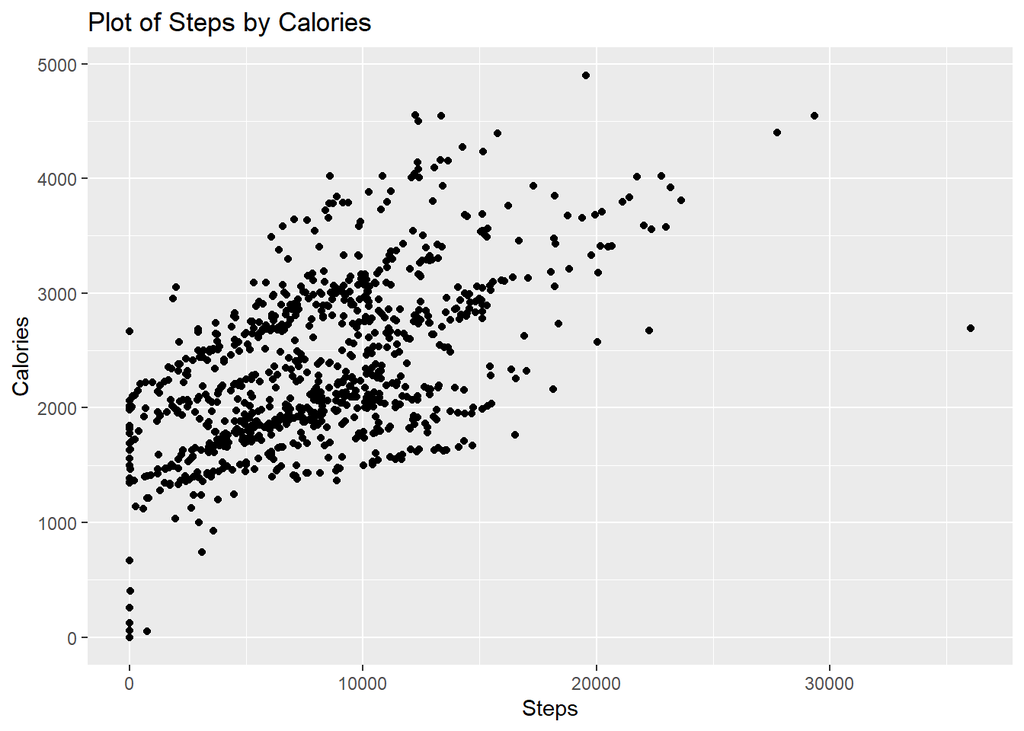

```r
calories <- hourly_calories %>% group_by(Id) %>%
  summarise(sum_calories=sum(Calories),
            .groups = 'drop')

steps <- hourly_steps %>% group_by(Id) %>%
  summarise(sum_steps=sum(StepTotal),
            .groups = 'drop')

calories_steps_corellation <- merge(calories, steps, by ="Id")
```

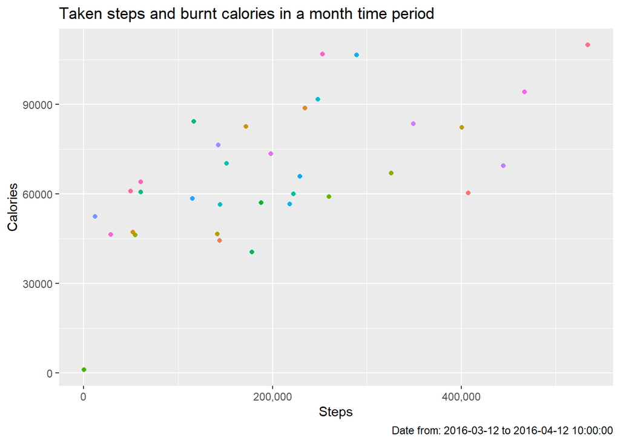

Moving on to another summary:

```r
sleep_day %>%
  select(total_sleep_records,
         total_minutes_asleep,
         total_time_in_bed) %>%
  summary()
```

```
##  total_sleep_records total_minutes_asleep total_time_in_bed
##  Min.   :1.000       Min.   : 58.0        Min.   : 61.0
##  1st Qu.:1.000       1st Qu.:361.0        1st Qu.:403.0
##  Median :1.000       Median :433.0        Median :463.0
##  Mean   :1.119       Mean   :419.5        Mean   :458.6
##  3rd Qu.:1.000       3rd Qu.:490.0        3rd Qu.:526.0
##  Max.   :3.000       Max.   :796.0        Max.   :961.0
```

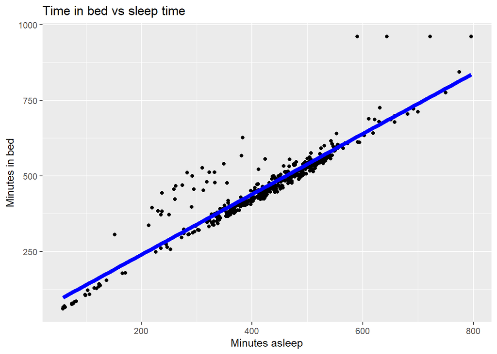

This visualization proves previous insight true. The trend line is very close to the points of this scatterplot which implies a strong correlation between minutes asleep and time spent in bed.

## Summary

In this Case Study I showed what I have learned in R programming regarding Data Analysis. I dowloaded and loaded dataset from a public source into RStudio, used some functions from tidyverse library, cleaned and processed the data, did few aggregation functions, plotted clear and easy to understand charts and managed to deliver a couple of insights based on the story that data showed me. I am open to constructive criticism on how to improve my skills and what could have bedn done better for next time. I am always open to acquiring new knowledge :)